# EDA of NYPD Shooting Report

Hidetake Takahashi

2021/9/20

### Table of Contents

1. Read Files
2. Analysis
3. Modeling
4. Conclusion and Bias

## Introduction

NYPD shooting report data consists of Location of incident, race and age of victims, Date and Time, etc which were occurred from 2006 to 2020. There are lots of Missing data (NA) in perpetrator’s information (PERP_RACE, etc) because they are not identified. However, if those information can be predicted, it will be helpful for investigation. Because of this interests, this report indicates relationship between Y (PERP_RACE) and X(VIC_RACE, OCCUR_TIME, LOCATION), then PERP_RACE is predicted by RandomForest Classifier.

## 1. Read Files

### 1.1 Libraries

```r
library(tidyverse)
library(lubridate)
library(igraph)
#library(sf)
#library(nycgeo)
library(randomForest)
```

```r
file_url <- "https://data.cityofnewyork.us/api/views/833y-fsy8/rows.csv?accessType=DOWNLOAD"

data_df <- read_csv(file_url)
```

### 1.2 Conversion of data types

Conversion of String into Factor let analysis easier. In addition, some new data is created such as OCCUR_WDAY.

```r
data_df <- data_df %>% mutate(OCCUR_DATE = mdy(OCCUR_DATE))
data_df <- data_df %>% mutate(OCCUR_TIME = hms(OCCUR_TIME))
data_df <- data_df %>% mutate(OCCUR_HOUR = hour(OCCUR_TIME))
data_df <- data_df %>% mutate(OCCUR_TIME= OCCUR_HOUR + minute(OCCUR_TIME)/60)


data_df <- data_df %>% mutate(BORO = as.factor(BORO))
data_df <- data_df %>% mutate(LOCATION_DESC = as.factor(LOCATION_DESC))
data_df <- data_df %>% mutate(PERP_AGE_GROUP = as.factor(PERP_AGE_GROUP))
data_df <- data_df %>% mutate(PERP_SEX = as.factor(PERP_SEX))

data_df <- data_df %>% mutate(PERP_RACE = as.factor(PERP_RACE))
data_df <- data_df %>% mutate(VIC_AGE_GROUP = as.factor(VIC_AGE_GROUP))
data_df <- data_df %>% mutate(VIC_SEX = as.factor(VIC_SEX))
data_df <- data_df %>% mutate(VIC_RACE = as.factor(VIC_RACE))
```

### 1.3 Perpetrators’ race

As mentioned in the introduction, there are large numbers of cases in which perpetrator is not identified. “NA” and “UNKNOWN” occupies more than 30% of cases.

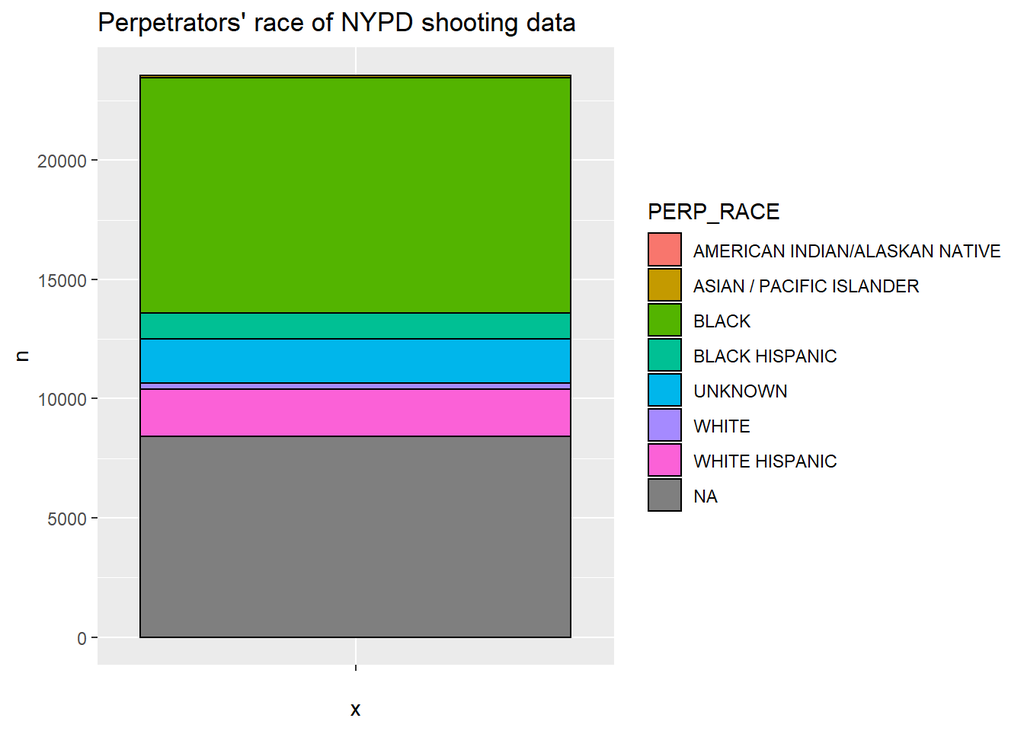

```r
count_perp <- data_df %>% group_by(PERP_RACE) %>% count()

count_perp %>%
  ggplot(aes(x="", y=n, fill=PERP_RACE)) +
  geom_bar(stat="identity", width=1, col = "black") +
  labs(title = "Perpetrators' race of NYPD shooting data")
```

## 2. Analysis

### 2.1 Geospatial Plot (Optional)

To execute following commands, `nycgeo` and `sf` packages shall be installed.

Map of NYC is loaded by `nyc_boundaries()` function of `nycgeo` package. To overlay map on incident data, map data should be converted to the Longitude-Latitude coordinate system (espg:4326).

```r
#geom_nyc <- st_transform(nyc_boundaries(), crs = "epsg:4326")
```

```r
#data_df %>% nrow()
```

```r
#perp_percinct <- data_df %>% filter(PERP_RACE != "UNKNOWN") %>%
#  filter(!is.na(PERP_RACE)) %>%
#  group_by(PRECINCT, PERP_RACE) %>%
#  summarize(count = n(), lon = mean(Longitude), lat = mean(Latitude))


#geom_nyc %>% ggplot() + geom_sf() + theme_void() +
#  geom_point(data = perp_percinct %>% filter(PERP_RACE != "AMERICAN INDIAN/ALASKAN NATIVE"),
#             aes(x = lon, y = lat, size = count, color = PERP_RACE, alpha = 0.3)) +
#  labs(title = "Geographical Distribution of incidents")
```

### 2.2 Distribution in Time

By plotting density in Occoured Time by each Perpetrator’s Race, distince features are obserbed. BLACK, BLACK-HISPANIC, and WHITE-HISPANIC have strong peak around midnight, whereas WHITE and ASIAN/PACIFIC ISLANDER has more distribution in day time.

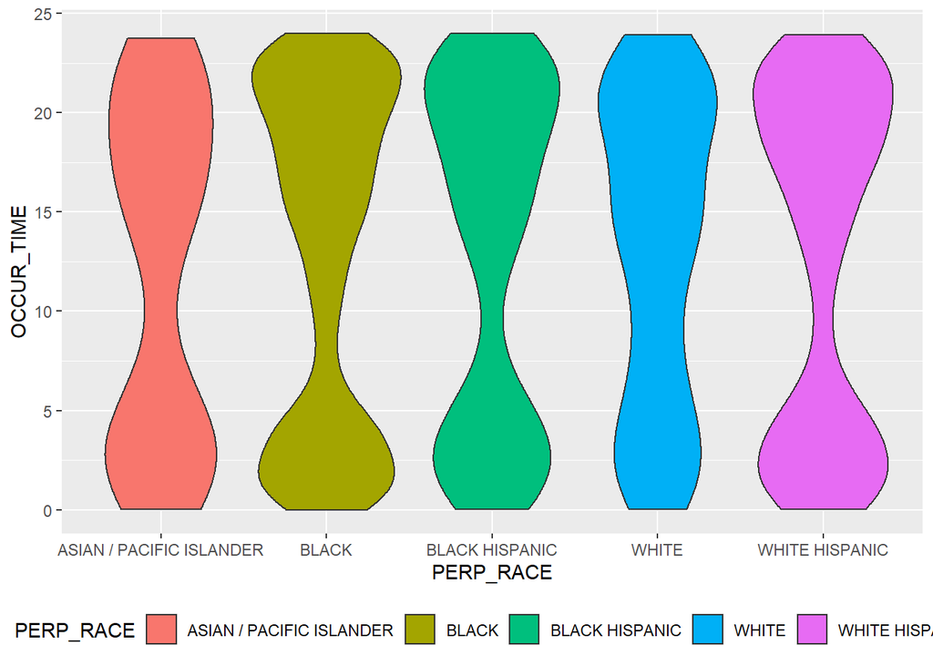

```r
data_df %>% filter(!is.na(PERP_RACE)) %>%
  filter(PERP_RACE != "UNKNOWN") %>%
  filter(PERP_RACE != "AMERICAN INDIAN/ALASKAN NATIVE") %>%
  ggplot(aes(x = PERP_RACE, y = OCCUR_TIME, fill = PERP_RACE)) + geom_violin() +
  theme(legend.position = "bottom")
```

### 2.3 Perpetrators and Victims

There must be strong relationships between races of perpetrators and victims, due to higher interaction within the same races.

It can be shown by counting incident by each PERP_RACE and VIC_RACE. There are, however, better way to visualize relationship between perpetrators and victims. First, to convert the data into graph object by `graph_from_data_frame` function of `igraph` packages.

In the graph plot, edges are colored (categorized) according to the count, and it shows higher number of incidents occours within the same race as expected.

```r
vic_by_perp <- data_df %>%
  filter(PERP_RACE != "UNKNOWN", VIC_RACE != "UNKNOWN") %>%
  group_by(PERP_RACE, VIC_RACE) %>%
  summarise(count = n()) %>%
  filter(count > 50) %>%
  mutate(color = ifelse(count < 400, "gray",
                        ifelse(count < 800, "darkgreen",
                        ifelse(count < 2000, "orange", "red")))) %>%
  mutate(weight = ifelse(count < 400, 1, ifelse(count< 800,2 ,
                                          ifelse(count < 2000, 3, 5))))

vic_by_perp <- vic_by_perp %>%
  mutate(count = as.numeric(count)) %>%
  as.data.frame()
```

```r
vic_by_perp %>% slice_max(count, n = 10) %>% dplyr::select(-c(color, weight))
```

```
##         PERP_RACE       VIC_RACE count
## 1           BLACK          BLACK  7826
## 2           BLACK WHITE HISPANIC  1031
## 3  WHITE HISPANIC WHITE HISPANIC   854
## 4           BLACK BLACK HISPANIC   676
## 5  WHITE HISPANIC          BLACK   630
## 6  BLACK HISPANIC          BLACK   444
## 7  WHITE HISPANIC BLACK HISPANIC   350
## 8  BLACK HISPANIC WHITE HISPANIC   307
## 9  BLACK HISPANIC BLACK HISPANIC   276
## 10          BLACK          WHITE   160
```

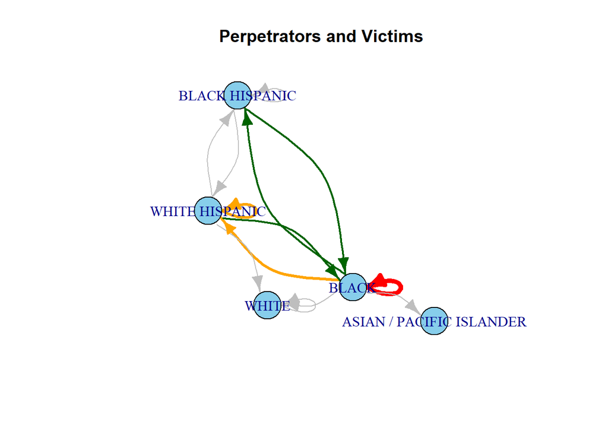

| count of incident | edge color |
| --- | --- |
| < 50 | (removed from graph) |
| < 400 | gray |
| < 800 | green |
| < 2000 | orange |
| >= 2000 | red |

```r
g <- graph_from_data_frame(d = vic_by_perp, directed = TRUE)

plot(g, edge.width = E(g)$weight,
     vertex.size=25, vertex.frame.color="black",
     vertex.color = "skyblue",
     edge.color = E(g)$color,
     layout=layout.kamada.kawai,
     label.color = "green",
     edge.curved=T,
     main = "Perpetrators and Victims")
```

### 2.4 Probability of Location

If there is differences of crime location between PERP_RACE, it is important factor to guess who committed it. According to the following raster plot (probability of location), most of crimes by BLACK and BLACK HISPANIC are in Multidwell residents while WHITE and ASIAN/PACIFIC ISLANDER has peak in Private house.

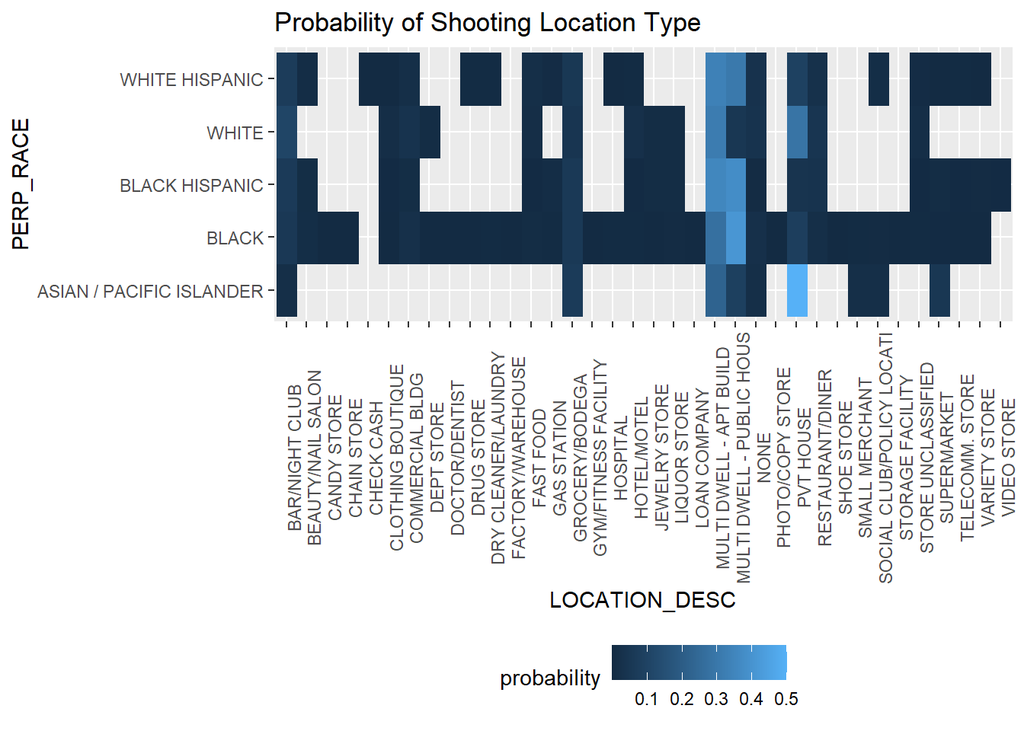

```r
place_perprace_fun <- function(df, perp_race){
  df2 <- df %>% filter(PERP_RACE == perp_race)
  df2$probability <- (df2$count)/sum(df2$count)

  return(df2)

}

place_perprace <- data_df %>%
  filter(!is.na(LOCATION_DESC)) %>%
  filter(PERP_RACE != "UNKONW", !is.na(PERP_RACE)) %>%
  group_by(LOCATION_DESC, PERP_RACE) %>%
  summarise(count = n())

place_perp_black <- place_perprace_fun(place_perprace, "BLACK")
place_perp_bhisp <- place_perprace_fun(place_perprace, "BLACK HISPANIC")
place_perp_whisp <- place_perprace_fun(place_perprace, "WHITE HISPANIC")
place_perp_white <- place_perprace_fun(place_perprace, "WHITE")
place_perp_asian <- place_perprace_fun(place_perprace, "ASIAN / PACIFIC ISLANDER")

place_perp_race2 <- place_perp_black %>%
  bind_rows(place_perp_bhisp, place_perp_whisp, place_perp_white, place_perp_asian)

place_perp_race2 %>%
  ggplot(aes(y = PERP_RACE, x = LOCATION_DESC, fill = probability)) +
  geom_raster() +
  theme(axis.text.x = element_text(angle = 90), legend.position = "bottom") +
  labs(title = "Probability of Shooting Location Type")
```

## 3. Modeling

In this chapter, prediction of PERP_RACE is attempted according to VIC_RACE, LOCATION_DESC, and OCCUR_TIME.

### 3.1 Preprocessing Data

Data frame for modeling is created by following commands.

```r
ml_df <- data_df %>%
  filter(PERP_RACE != "UNKNOWN", VIC_RACE != "AMERICAN INDIAN/ALASKAN NATIVE") %>%
  filter(VIC_RACE != "UNKNOWN", VIC_RACE != "AMERICAN INDIAN/ALASKAN NATIVE") %>%
  filter(LOCATION_DESC != "UNKNOWN",LOCATION_DESC != "NONE") %>%
  dplyr::select(PERP_RACE,  VIC_RACE, LOCATION_DESC, OCCUR_TIME)

ml_df$PERP_RACE <- ml_df$PERP_RACE %>%
  droplevels(c("AMERICAN INDIAN/ALASKAN NATIVE", "UNKNOWN"))
ml_df$VIC_RACE <- ml_df$VIC_RACE %>%
    droplevels(c("AMERICAN INDIAN/ALASKAN NATIVE", "UNKNOWN"))

ml_df <- ml_df %>% drop_na()
```

```r
set.seed(100)
n <- nrow(ml_df)
index_shuffle <- sample(1:n)
train_index <- index_shuffle[1:as.integer(n*0.7)]
test_index <- index_shuffle[(as.integer(n*0.7)+1):n]
train_df <- ml_df[train_index,]
test_df <- ml_df[test_index,]
```

### 3.2 RandomForest Classifier

RandomForest Classifier of `randomForest` package is trained by `train_df`.

```r
# class of PERP_RACE is:
# "ASIAN / PACIFIC ISLANDER", "BLACK", "BLACK HISPANIC", "WHITE", "WHITE HISPANIC"

weights <- c(1,1,1,1,1)
set.seed(100)
model_tree <- randomForest( formula = PERP_RACE ~ VIC_RACE + LOCATION_DESC + OCCUR_TIME, data = train_df, classwt = weights)

summary(model_tree)
```

```
##                 Length Class  Mode
## call                4  -none- call
## type                1  -none- character
## predicted        4140  factor numeric
## err.rate         3000  -none- numeric
## confusion          30  -none- numeric
## votes           20700  matrix numeric
## oob.times        4140  -none- numeric
## classes             5  -none- character
## importance          3  -none- numeric
## importanceSD        0  -none- NULL
## localImportance     0  -none- NULL
## proximity           0  -none- NULL
## ntree               1  -none- numeric
## mtry                1  -none- numeric
## forest             14  -none- list
## y                4140  factor numeric
## test                0  -none- NULL
## inbag               0  -none- NULL
## terms               3  terms  call
```

```r
set.seed(100)
pred <- predict(object = model_tree, newdata = train_df, type = "class")
train_df$pred <- pred

pred <- predict(object = model_tree, newdata = test_df, type = "class")
test_df$pred <- pred
```

### 3.3 Result

Accuracy is measured by test data (`test_df`). Overall accuracy is 70%. Black HISPANIC has lowest accuracy, because they are confused with BLACK.

**Overall Accuracy**

```r
sum(test_df$PERP_RACE == test_df$pred)/nrow(test_df)
```

```
## [1] 0.7025352
```

**Accuracy of each Race**

```r
correct <- test_df %>% filter(pred == PERP_RACE) %>% group_by(pred) %>% summarise(count = n())
overall <- test_df %>% group_by(PERP_RACE) %>% summarise(count = n())

overall$accuracy <- correct$count/overall$count

overall %>% dplyr::select(-count)
```

```
## # A tibble: 5 x 2
##   PERP_RACE                accuracy
##   <fct>                       <dbl>
## 1 ASIAN / PACIFIC ISLANDER    0.588
## 2 BLACK                       0.809
## 3 BLACK HISPANIC              0.194
## 4 WHITE                       0.684
## 5 WHITE HISPANIC              0.399
```

**BLACK-HISPANIC result**

66 cases are confused with BLACK.

```r
test_df %>% filter(PERP_RACE == "BLACK HISPANIC") %>%
  group_by(pred) %>%
  summarise(count = n())
```

```
## # A tibble: 5 x 2
##   pred                     count
##   <fct>                    <int>
## 1 ASIAN / PACIFIC ISLANDER     3
## 2 BLACK                       66
## 3 BLACK HISPANIC              26
## 4 WHITE                        4
## 5 WHITE HISPANIC              35
```

## 4. Conclusion and Bias

Overall accuracy of prediction of PERP_RACE is about 70% which is fairly good for such small numbers of variables: VIC_RACE, LOCATION_DESC, OCCUR_TIME). It must be possible to support investigation by Machine Learning, because in the actual investigation, more detail information are available which increases accuracy.

However, according to the Confusion Matrix, PERP_RACE = BLACK HISPANIC is mostly confused with BLACK. It happens due to larger amount of cases of BLACK and similar distribution of LOCATION_DESC between BLACK and BLACK HISPANIC. Machine learning result seems to be biased just like human’s guess would be.

Furthermore, to prevent technical error (empty class) of RandomForest, very minor cases, “AMERICAN INDIAN/ALASKAN NATIVE”, were removed from data. It would also create a bias for predicting PERP_RACE by ignoring AMERICAN INDIAN/ALASKAN NATIVE’s involvement.